# Unit I: Climate Change Module

## Opening Tutorial: Examining CO2 trends in python

- Example from http://climate.nasa.gov/vital-signs/carbon-dioxide/
- Raw data from https://gml.noaa.gov/webdata/ccgg/trends/co2/co2_mm_mlo.txt

```python
import pandas as pd
import seaborn.objects as sopip
```

```python
columns = ['year', 'month', 'decimal_date', 'average', 'smooth', 'std_days', 'uncertainty', 'empty']
df = pd.read_csv("https://gml.noaa.gov/webdata/ccgg/trends/co2/co2_mm_mlo.txt", sep="\s+", comment="#", names= columns)
df
```

|  | year | month | decimal_date | average | smooth | std_days | uncertainty | empty |
| --- | --- | --- | --- | --- | --- | --- | --- | --- |
| 0 | 1958 | 3 | 1958.2027 | 315.71 | 314.44 | -1 | -9.99 | -0.99 |
| 1 | 1958 | 4 | 1958.2877 | 317.45 | 315.16 | -1 | -9.99 | -0.99 |
| 2 | 1958 | 5 | 1958.3699 | 317.51 | 314.69 | -1 | -9.99 | -0.99 |
| 3 | 1958 | 6 | 1958.4548 | 317.27 | 315.15 | -1 | -9.99 | -0.99 |
| 4 | 1958 | 7 | 1958.5370 | 315.87 | 315.20 | -1 | -9.99 | -0.99 |
| ... | ... | ... | ... | ... | ... | ... | ... | ... |
| 793 | 2024 | 4 | 2024.2917 | 426.51 | 423.99 | 22 | 0.99 | 0.40 |
| 794 | 2024 | 5 | 2024.3750 | 426.90 | 423.62 | 29 | 0.76 | 0.27 |
| 795 | 2024 | 6 | 2024.4583 | 426.91 | 424.45 | 20 | 0.65 | 0.28 |
| 796 | 2024 | 7 | 2024.5417 | 425.55 | 425.07 | 24 | 0.69 | 0.27 |
| 797 | 2024 | 8 | 2024.6250 | 422.99 | 424.85 | 22 | 1.07 | 0.44 |

798 rows × 8 columns

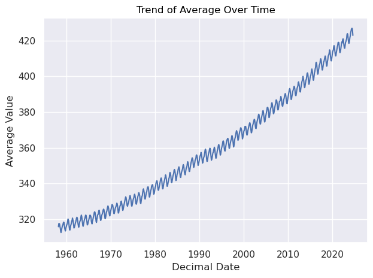

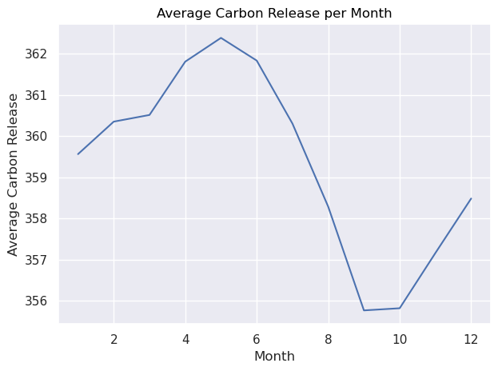

```python
import seaborn.objects as so
import pandas as pd
import matplotlib.pyplot as plt
(
    so.Plot(df, x="decimal_date", y="average")
    .add(so.Line())
    .label(x="Decimal Date", y="Average Value", title="Trend of Average Over Time")
    .show()
)
monthly_avg = df.groupby('month')['average'].mean().reset_index()

monthly_plot = (
    so.Plot(monthly_avg, x="month", y="average")
    .add(so.Line())
    .label(x="Month", y="Average Carbon Release", title="Average Carbon Release per Month")
    .show()
)
```

**Which months are the CO2 values at the maximum? Minimum? Why is this?**

**What rolling average is used in computing the "trend" line? How does the trend depend on the rolling average?**

- This rolling average should be (and is) a simple rolling average that taeks every value at equal weight and computes the average per unit over time.

# Temperature Data

Each of the last years has consecutively set new records on global climate. In this section we will analyze global mean temperature data.

Data from: http://climate.nasa.gov/vital-signs/global-temperature

## Question 1:

Describe the data set to the best of your ability given the documentation provided. Describe what kind of column each data contains and what units it is measured in. Then address our three key questions in understanding this data:

The data shows three columns: year, no_smoothing, and lowess(5). It tells us the temperature anomolies, and how drastic they were, over time. The numbers in the lowess columns are a statistically manipulated value that locally weights the scatter plot in order to smooth the data and show a more general trend by averaging short term drastic fluctuations. This data is recorded in celsius.

- **How are the measurements made? What is the associated measurement uncertainty?**
- This data is collected from a range of scientific instruments, such as sattelite data, weather balloon, ships, and meteroligcal stations across the world. The measurement uncertainty therefore comes from possible faulty instrument percision, and graps across areas of the world where sampling may have been less.
- **What is the resolution of the data?**
- The temporal resolution is one year, and the spatial resolution is global.
- **Are their missing values? How should they be handled?**
- There are no obviously visible missing values from this data set, but if there were they should be removal (leaving the bad data out of the analysis) or use imputation to accurately assume what the data point should be in according to the data points around it.

## Question 2:

Construct the necessary python code to import and prepare for manipulation the following data set: http://climate.nasa.gov/system/internal_resources/details/original/647_Global_Temperature_Data_File.txt

```python
df1 = pd.read_csv("https://climate.nasa.gov/system/internal_resources/details/original/647_Global_Temperature_Data_File.txt", sep="\s+", comment="#", skiprows=5, names=['year', 'temp', 'smooth'])
print(df1.head())
df1_clean = df1.dropna()
```

```
   year  temp  smooth
0  1880 -0.16   -0.09
1  1881 -0.08   -0.13
2  1882 -0.11   -0.16
3  1883 -0.17   -0.20
4  1884 -0.28   -0.24
```

## Question 3:

**Plot the trend in global mean temperatures over time. Describe what you see in the plot and how you interpret the patterns you observe.**

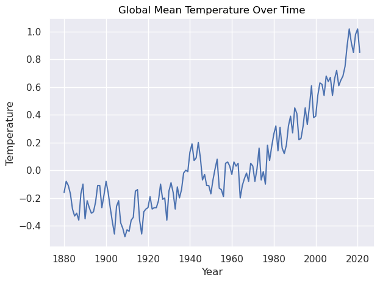

```python
so.Plot(df1_clean, x="year", y="temp") \
    .add(so.Line()) \
    .label(x="Year", y="Temperature", title="Global Mean Temperature Over Time") \
    .show()
```

# Exercise II: Melting Ice Sheets?

- Data description: http://climate.nasa.gov/vital-signs/land-ice/
- Raw data file: http://climate.nasa.gov/system/internal_resources/details/original/499_GRN_ANT_mass_changes.csv

## Question 1:

- **Describe the data set: what are the columns and units? Where do the numbers come from?**
- The 'TIME' column is measured in decimal year (2002.29 = 29% into 2002) in order to have a more accurate account for when the data was collected. The data greenland and anarctica shows the mass (gigatons) of ice sheet in that area. This data comes from NASA’s GRACE (Gravity Recovery and Climate Experiment) which track earths gravitational field, allowing scientists to estimate ice sheet mass in very large areas.
- **What is the uncertainty in measurment? Resolution of the data? Interpretation of missing values?**
- There could be uncertainty from machine and data processing error. The gap in data occured while GRACE was being paused and GRACE-FO (its predecessor) was launched. The spatial resolution is regional and the temporal resolution is sub-annual.

## Question 2:

Construct the necessary code to import this data set.

```python
mi_data  = pd.read_csv (
    '499_GRN_ANT_mass_changes.csv',
    skiprows=9
)
mi_data
```

|  | TIME (year.decimal) | Greenland mass (Gt) | Antarctica mass (Gt) |
| --- | --- | --- | --- |
| 0 | 2002.29 | 1490.68 | 967.20 |
| 1 | 2002.35 | 1485.69 | 978.55 |
| 2 | 2002.62 | 1286.84 | 512.02 |
| 3 | 2002.71 | 1257.85 | 858.85 |
| 4 | 2002.79 | 1257.17 | 693.87 |
| ... | ... | ... | ... |
| 135 | 2014.45 | -1672.08 | -1021.70 |
| 136 | 2014.62 | -1985.59 | -1067.84 |
| 137 | 2014.71 | -2024.82 | -780.87 |
| 138 | 2014.79 | -1973.96 | -904.38 |
| 139 | 2014.88 | -1911.78 | -1009.80 |

140 rows × 3 columns

## Question 3:

**Plot the data and describe the trends you observe.**

Over time, the amount of ice mass has declined in both Antarctica and Greenland. Overall, Greenlands pattern of decline was steeper, meaning their loss of ice was much faster and more intense than Anarctica.

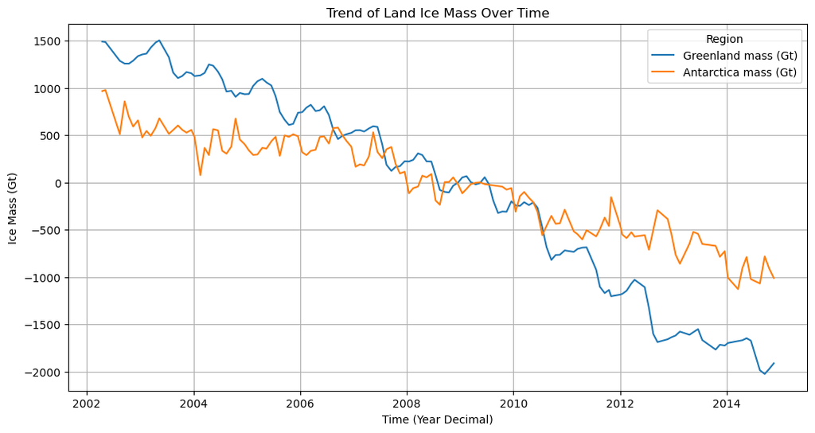

```python
import pandas as pd
import seaborn as sns
import matplotlib.pyplot as plt


mi_data_melted = mi_data.melt(id_vars='TIME (year.decimal)',
                                value_vars=['Greenland mass (Gt)', 'Antarctica mass (Gt)'],
                                var_name='region',
                                value_name='mass')
plt.figure(figsize=(12, 6))
sns.lineplot(data=mi_data_melted, x='TIME (year.decimal)', y='mass', hue='region')

plt.title('Trend of Land Ice Mass Over Time')
plt.xlabel('Time (Year Decimal)')
plt.ylabel('Ice Mass (Gt)')
plt.legend(title='Region')
plt.grid()
plt.show()
```

# Exercise III: Rising Sea Levels?

- Data description: http://climate.nasa.gov/vital-signs/sea-level/
- Raw data file: http://climate.nasa.gov/system/internal_resources/details/original/121_Global_Sea_Level_Data_File.txt

## Question 1:

- **Describe the data set: what are the columns and units?**
- The columns are:
- altimeter_type, which is the tyoe of sattelite altimeter used to collect data.  
  cycle_number, which is the number of orbit cycles that sattelite has completed when the data is collected  
  year_fraction, year in decimal form for increased time accuracy  
  num_observations, number of obseravtions completed by sattelite  
  num_weighted_observations, weighted (to quality) number of obseravtions completed by sattelite GMSL_variation_GIA_not_applied, variation in Global Mean Sea Level (GMSL) without correction for Glacial Isostatic Adjustment (GIA, which accounts for earths rebound after melting)  
  std_dev_GMSL_GIA_not_applied, std deviation of variation in GMSL without accounting for GIA  
  smoothed_GMSL_GIA_not_applied, smoothed (short term flucuations) GMSL variation without GIA  
  GMSL_variation_GIA_applied, variation of GMSL accounting for GIA  
  std_dev_GMSL_GIA_applied, std deviation of variation in GMSL accounting for GIA smoothed_GMSL_GIA_applied, smoothed (short term flucuations) GMSL variation accounting for GIA smoothed_GMSL_annual_semi_annual_removed, smoothed GSML variations with smoothed annual fluctions (summer/winter)
- **Where do these data come from?**
- satellite altimetry measurements of global sea level, this data specifically comes form NASA’s Goddard Space Flight Center.
- **What is the uncertainty in measurment? Resolution of the data? Interpretation of missing values?**
- Measurement uncertainty can come from instrumental uncertainty when its takin gmeasurmenets, uncertainty from an over/undercorrection from the GIA, and statistical error in data smoothing. The temporal resolution is sub annual , and the spatial resolution is large scale, global oceans.

## Question 2:

Construct the necessary code to import this data set as tidy.

```python
import pandas as pd
import seaborn.objects as sopip
import matplotlib.pyplot as plt

columns = [
    'altimeter_type',
    'cycle_number',
    'year_fraction',
    'num_observations',
    'num_weighted_observations',
    'GMSL_variation_GIA_not_applied',
    'std_dev_GMSL_GIA_not_applied',
    'smoothed_GMSL_GIA_not_applied',
    'GMSL_variation_GIA_applied',
    'std_dev_GMSL_GIA_applied',
    'smoothed_GMSL_GIA_applied',
    'smoothed_GMSL_annual_semi_annual_removed'
]
rsl = pd.read_csv(
    ' http://climate.nasa.gov/system/internal_resources/details/original/121_Global_Sea_Level_Data_File.txt',
    sep=r'\s+',
    comment='H',
    skiprows=22,
    header=None,
    names=columns
)



rsl = rsl[rsl['altimeter_type'] != -9999] #Missing or bad value flag: 99900.000
print(rsl)
```

```
     altimeter_type  cycle_number  year_fraction  num_observations  \
0                 0            11    1993.014526            463892
1                 0            12    1993.041626            458154
2                 0            13    1993.068848            469524
3                 0            14    1993.095947            419112
4                 0            15    1993.123169            456793
..              ...           ...            ...               ...
842               0           854    2015.901856            472216
843               0           855    2015.928955            473526
844               0           856    2015.956177            473929
845               0           857    2015.983276            476782
846               0           858    2016.010498            475082

     num_weighted_observations  GMSL_variation_GIA_not_applied  \
0                    336484.59                          -13.74
```

[output cut: 51 more lines]

## Question 3:

**Plot the data and describe the trends you observe.** The Global Mean Sea Level (GMSL)when accounting for the Glacial Isostatic Adjustment, is pretty quickly increasing since 1995 to 2015 - with a steeper increase in sea level more recently.

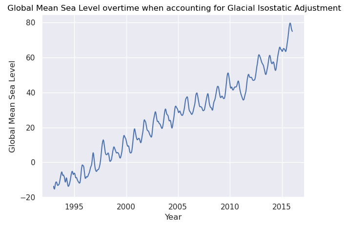

```python
import seaborn.objects as so
import matplotlib.pyplot as plt

(
    so.Plot(rsl, x='year_fraction', y='smoothed_GMSL_GIA_applied')
    .add(so.Line())
    .label(x="Year", y= "Global Mean Sea Level", title=" Global Mean Sea Level overtime when accounting for Glacial Isostatic Adjustment") \
    .show()
)
```

# Exercise IV: Arctic Sea Ice?

- http://nsidc.org/data/G02135
- https://noaadata.apps.nsidc.org/NOAA/G02135/north/monthly/data/

## Question 1:

- **Describe the data set: what are the columns and units?**
- The columns are: year, month, data type, region, extent, and area. The units are year, month, data type = categorical (Goddard Space Flight Center), region = categroical (northern alantic region), extent = Million square kilometers (M km²)(total area where sea ice concentration is at least 15%.), area = Million square kilometers (M km²), (actual area of ocean covered by sea ice)
- **Where do these data come from?**
- This data comes from measurements taken by NASA's Goddard Space Flight Center.
- **What is the uncertainty in measurement? Resolution of the data? Interpretation of missing values?**
- Missing or bad value flag: 99900.000, so these values are removed. Temporal resolution is per month of each year, and spatial resolution of satelites is usually 10-20km in the northern alantic region. The uncertainty could come from machine mistake (can be caused by weather, etc.) or data processing mistakes.

## Question 2:

Construct the necessary code to import this data set

```python
import pandas as pd
asi = pd.read_csv("https://noaadata.apps.nsidc.org/NOAA/G02135/north/monthly/data/N_01_extent_v3.0.csv",
                  sep=",", comment="#", names=['year', 'mo', 'data-type', 'region', 'extent', 'area']
                 ,skiprows=1)
asi = asi[asi['extent'] != -9999] #Missing or bad value flag: 99900.000
print(asi)
```

```
    year  mo      data-type   region  extent   area
0   1979   1        Goddard        N   15.41  12.41
1   1980   1        Goddard        N   14.86  11.94
2   1981   1        Goddard        N   14.91  11.91
3   1982   1        Goddard        N   15.18  12.19
4   1983   1        Goddard        N   14.94  12.01
5   1984   1        Goddard        N   14.47  11.68
6   1985   1        Goddard        N   14.72  11.69
7   1986   1        Goddard        N   14.89  11.88
8   1987   1        Goddard        N   14.97  11.90
10  1989   1        Goddard        N   14.95  13.18
11  1990   1        Goddard        N   14.78  12.80
12  1991   1        Goddard        N   14.36  12.57
13  1992   1        Goddard        N   14.64  12.61
14  1993   1        Goddard        N   14.90  12.93
```

[output cut: 31 more lines]

## Question 3:

**Plot the data and describe the trends you observe.**

The extent of ice covering the area has steadily decreased since 1980. A little before 2020 the extent of ice coverage has increased slowly.

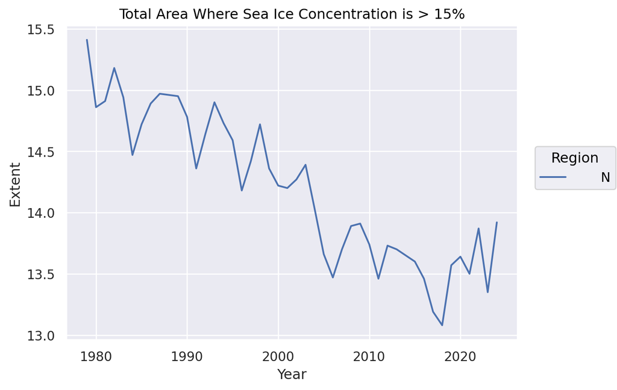

```python
import seaborn.objects as so
import pandas as pd
import matplotlib.pyplot as plt
plot = (

    so.Plot(asi, x="year", y="extent", color="region")
    .label(x="Year", y="Extent", color="Region", title="Total Area Where Sea Ice Concentration is > 15%")
    .add(so.Line())
)
plot
```